# RICHARDS_Skills_Test_3

Jessica Richards

2024-11-21

# 1a - Cleaning Faculty Salaries Data

Cleaning the data was a bit of a long process but I was able to elongate the data so that there was a column for Rank, Salary, Comp and Number.

```r
dat <- read.csv('FacultySalaries_1995.csv')

dat_keep <- dat %>%
  select(-c(AvgProfSalaryAll, AvgProfCompAll, NumInstructors, NumFacultyAll))

dat_both <- dat_keep %>%
  select(-c(starts_with('Num')))

dat_salary <- dat_both %>%
  select(-c(ends_with('Comp'))) %>%
rename('Full' = 'AvgFullProfSalary',
       'Assoc' = 'AvgAssocProfSalary',
       'Assist' = 'AvgAssistProfSalary') %>%
  pivot_longer(c('Full', 'Assoc', 'Assist'), names_to = 'Rank', values_to = 'Salary')

dat_comp <- dat_both %>%
  select(-c(ends_with('Salary'))) %>%
rename('Full' = 'AvgFullProfComp',
       'Assoc' = 'AvgAssocProfComp',
       'Assist' = 'AvgAssistProfComp') %>%
  pivot_longer(c('Full', 'Assoc', 'Assist'), names_to = 'Rank', values_to = 'Comp')

dat_num <- dat_keep %>%
  select(-c(starts_with('Avg'))) %>%
   rename('Full' = 'NumFullProfs',
         'Assoc' = 'NumAssocProfs',
         'Assist' = 'NumAssistProfs') %>%
  pivot_longer(c('Full', 'Assoc', 'Assist'), names_to = 'Rank', values_to = 'Number')

dat_clean <- dat_num %>%
  full_join(dat_comp) %>%
  full_join(dat_salary) %>%
  filter(Tier != 'VIIB')
```

This is a sneak peak of the cleaned Faculty Salaries Data.

```r
head(dat_clean)
```

```
## # A tibble: 6 × 8
##   FedID UnivName                  State Tier  Rank   Number  Comp Salary
##   <int> <chr>                     <chr> <chr> <chr>   <int> <int>  <int>
## 1  1061 Alaska Pacific University AK    IIB   Full        6   567    454
## 2  1061 Alaska Pacific University AK    IIB   Assoc      11   485    382
## 3  1061 Alaska Pacific University AK    IIB   Assist      9   471    362
## 4  1063 Univ.Alaska-Fairbanks     AK    I     Full       74   914    686
## 5  1063 Univ.Alaska-Fairbanks     AK    I     Assoc     125   753    560
## 6  1063 Univ.Alaska-Fairbanks     AK    I     Assist    118   572    432
```

# 1b Graphing Faculty Salaries Data

The graphs are separated by Tier and show how average salaries of professors are affected by both Rank and Tier.

Based on the graph, Tier I professors on average make the most while Tier IIB professors make the least. Full professors in all tiers make the most while Assistant professors in all tiers make the least.

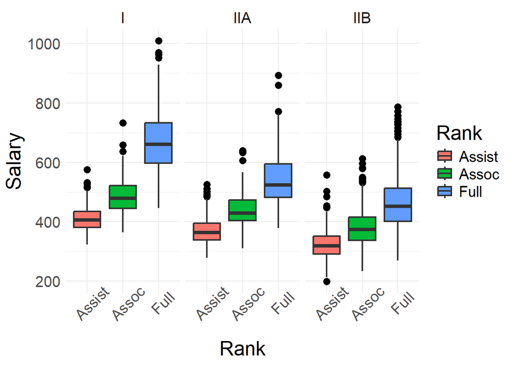

# 2 Creating an Anova Model of Faculty Salaries

Based on the anova summary, State, Tier and Rank all significantly affect the average salary of professors.

```r
anova_model <- aov(data = dat_clean, Salary ~ State + Tier + Rank)
summary(anova_model)
```

```
##               Df   Sum Sq Mean Sq F value Pr(>F)
## State         50  5667124  113342   31.17 <2e-16 ***
## Tier           2  7072361 3536180  972.56 <2e-16 ***
## Rank           2 16526626 8263313 2272.66 <2e-16 ***
## Residuals   3297 11987752    3636
## ---
## Signif. codes:  0 '***' 0.001 '**' 0.01 '*' 0.05 '.' 0.1 ' ' 1
## 128 observations deleted due to missingness
```

# 3 Cleaning Juniper Oils Data

To clean this dataset I tidied the names using clean_names in the janitor package, then replaced any underscores with hyphens to match the chemical name set provided in the instructions. I then elongated the data so that all of the chemical names were under chemical_id, and the concentrations were under concentration. Finally I once again used clean_names to change hyphens in column names to underscores.

```r
dat_oils <- read.csv('Juniper_Oils.csv')

dat_oils <- dat_oils %>%
  clean_names() %>%
  rename_with(~ gsub("_", "-", .))

dat_oils_clean <- dat_oils %>%
  pivot_longer( cols = c("alpha-pinene","para-cymene","alpha-terpineol",
                         "cedr-9-ene","alpha-cedrene","beta-cedrene",
                         "cis-thujopsene","alpha-himachalene","beta-chamigrene",
                         "cuparene","compound-1","alpha-chamigrene","widdrol",
                         "cedrol","beta-acorenol","alpha-acorenol",
                         "gamma-eudesmol","beta-eudesmol","alpha-eudesmol",
                         "cedr-8-en-13-ol","cedr-8-en-15-ol","compound-2",
                         "thujopsenal"),
                names_to = 'ChemicalID',
                values_to = 'Concentration') %>%
  clean_names()
```

This is a sneak peak of the cleaned Juniper Oils Data.

Since there are so many columns it doesn’t display well, but the most important things are that there are now columns for chemical_id and concentration, instead of a ton of columns for each individual chemical.

```
## # A tibble: 6 × 20
##   sample_id    project     amplicon tree_species    burn_year latitude longitude
##   <chr>        <chr>       <chr>    <chr>               <int>    <dbl>     <dbl>
## 1 LOG-16S-SL12 JuniperLogs 16S      Juniperus oste…      2018     41.6     -114.
## 2 LOG-16S-SL12 JuniperLogs 16S      Juniperus oste…      2018     41.6     -114.
## 3 LOG-16S-SL12 JuniperLogs 16S      Juniperus oste…      2018     41.6     -114.
## 4 LOG-16S-SL12 JuniperLogs 16S      Juniperus oste…      2018     41.6     -114.
## 5 LOG-16S-SL12 JuniperLogs 16S      Juniperus oste…      2018     41.6     -114.
## 6 LOG-16S-SL12 JuniperLogs 16S      Juniperus oste…      2018     41.6     -114.
## # ℹ 13 more variables: field_office <chr>, blm_fire_name <chr>,
## #   tracking_number <chr>, yield_percent <dbl>, bolt_surface_area_cm2 <int>,
## #   raw_exit_holes_per_cm2 <dbl>, raw_exit_holes <int>, living_larvae <int>,
## #   chem_total <dbl>, chem_mean <dbl>, years_since_burn <int>,
## #   chemical_id <chr>, concentration <dbl>
```

# 4 Graphing Juniper Oils Data

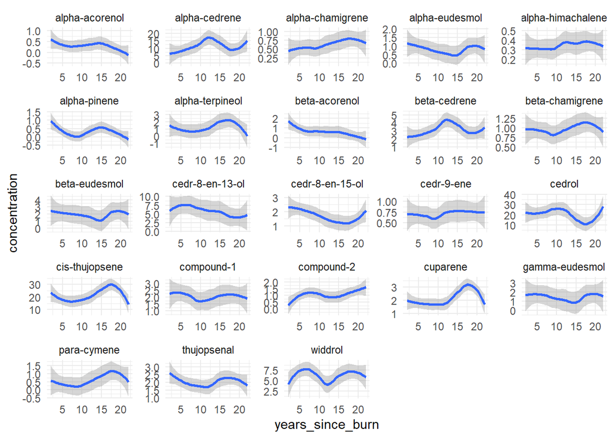

# 5 Modeling Juniper Oils Data

```r
model <- glm(data = dat_oils_clean, concentration ~ years_since_burn * chemical_id)
tidy_model <- tidy(model) %>%
  filter(p.value < 0.05)

head(tidy_model)
```

```
## # A tibble: 6 × 5
##   term                                     estimate std.error statistic  p.value
##   <chr>                                       <dbl>     <dbl>     <dbl>    <dbl>
## 1 chemical_idalpha-cedrene                    7.88      1.93       4.08 4.97e- 5
## 2 chemical_idcedr-8-en-13-ol                  7.62      1.93       3.95 8.72e- 5
## 3 chemical_idcedrol                          22.5       1.93      11.7  5.12e-29
## 4 chemical_idcis-thujopsene                  17.3       1.93       8.95 2.93e-18
## 5 chemical_idwiddrol                          5.82      1.93       3.01 2.69e- 3
## 6 years_since_burn:chemical_idcis-thujops…    0.332     0.141      2.35 1.90e- 2
```